# Progress Report paccmann_gp

### 3: Changing Temperature in SamplingSearch

**Thoughts:**

- Distributions are very wide and the median of each point is equal: possible reason why the optimisation process is not very effective
- Attempt to change the distributions and median value sof each point by changing the sampling

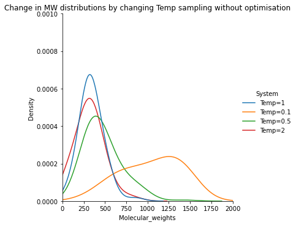

```python
sns.displot(dat_t_evaluation, kind='kde',x='Molecular_weights',hue='System',bw_adjust=2)
plt.xlim(0, 2000)
plt.ylim(0, 0.001)
plt.title('Change in MW distributions by changing Temp sampling without optimisation')
```

#### Distribution per point

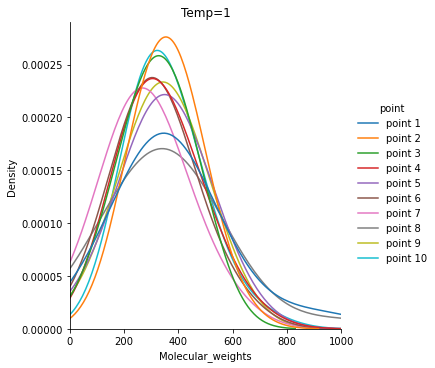

```python
sns.displot(dat_unopt_sampling, kind='kde',x='Molecular_weights',hue='point',bw_adjust=2)
plt.xlim(0, 1000)
plt.title('Temp=1')
```

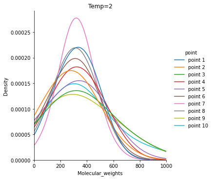

```python
sns.displot(dat_unopt_t2, kind='kde',x='Molecular_weights',hue='point',bw_adjust=2)
plt.xlim(0, 1000)
plt.title('Temp=2')
```

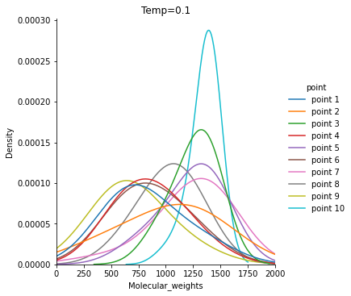

```python
sns.displot(dat_unopt_t01, kind='kde',x='Molecular_weights',hue='point',bw_adjust=2)
plt.xlim(0, 2000)
plt.title('Temp=0.1')
```

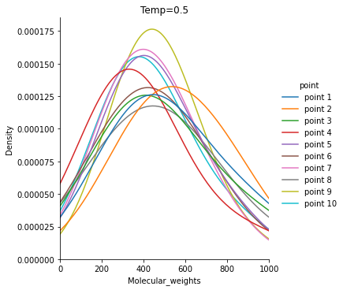

```python
sns.displot(dat_unopt_t05, kind='kde',x='Molecular_weights',hue='point',bw_adjust=2)
plt.xlim(0, 1000)
plt.title('Temp=0.5')
```

**Conclusion:**

- Median value for each point becomes distinct as Temp is decreased
- Might help for optimisation

#### MW Optimisation with reduced Temp

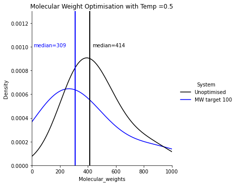

```python
sns.displot(dat_mw100_t05_comb, kind='kde',x='Molecular_weights',hue='System',bw_adjust=2,palette=['k','b'])
plt.axvline(x=dat_unopt_t05.Molecular_weights.median(), linewidth=2, color='k' )
plt.text(430,0.001,'median='+str("%.0f"%dat_unopt_t05.Molecular_weights.median()))
plt.axvline(x=dat_mw100_t05.Molecular_weights.median(), linewidth=2, color='b' )
plt.text(10,0.001,'median='+str("%.0f"%dat_mw100_t05.Molecular_weights.median()),color='b')
plt.xlim(0, 1000)
plt.ylim(0, 0.0013)
plt.title('Molecular Weight Optimisation with Temp =0.5')
plt.savefig('week1_2.png',bbox_inches='tight')
```

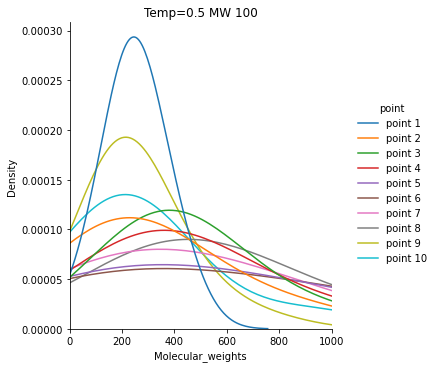

```python
sns.displot(dat_mw100_t05, kind='kde',x='Molecular_weights',hue='point',bw_adjust=2)
plt.xlim(0, 1000)
plt.title('Temp=0.5 MW 100')
```

**Conclusion:**

### Errors and notes

**ERRORS:**

**GENERATOR RELATED:**

imgs = [Chem.MolFromSmiles(s, sanitize=True) for s in smiles] TypeError: No registered converter was able to produce a C++ rvalue of type std::**1::basic_string<wchar_t, std::**1::char_traits, std::__1::allocator > from this Python object of type int

**QED**

".../site-packages/rdkit/Chem/QED.py", line 245, in properties mol = Chem.RemoveHs(mol)

**SA**

File ".../paccmann_generator/drug_evaluators/sas.py", line 74, in sa_score score1 /= nf ZeroDivisionError: float division by zero

**Optimization process**

RecursionError: maximum recursion depth exceeded (when T is very low)

**Observations:**

1. Smiles generator has to loop a lot as many smiles outputs are not valid --> Slow optimisation
2. Often distributions of MW/SA/QED for different points have same wide distribution with same median --> so optimsation tricky
3. Might need to check which molecules get discarded could affect MW distribution

## Appendix - Week 2

**Changes to files:**

- Adopted new structure: with an abstract minimisation class and a DecoderBasedMinimization
- instead of generating one smiles from latent point during the optimisation: fed in a batch of 30
- Note a MW optimisation with a batch of 30 does not mean the 30 MW are evaluated for each assessed latent point as many generated smiles are not valid
- Note: used more realistic MW targets for MW optimisation
- created an exception in the smiles generator
- Started looking at target affinity

  ```
    Q: 1. create a class with affinity predictor input creation or straight into code?
       2. create new minimization class Decoder and Affinity predictor
  ```

**Tests:**

- Evaluate the use of batch instead of smiles for one latent point during optimisation

  ```
    * For MW=200, MW=500, SA
  ```

- Increase optimisation by setting n_calls=200 and n_intial=100 (before 100, 20)

#### Imports

```python
import matplotlib.pyplot as plt
from statistics import mean, median
import seaborn as sns
import pandas as pd
```

#### File loading

```python
def file_loading_format_index_mw_qed_sa(files):
    smiles_index = []
    molecular_weights = []
    qed_scores = []
    sa_scores = []
    point_index = []
    p_i = 0
    for file in files:
        p_i+=1
        with open(file, 'r') as f:
            f.readline()
            for line in f:
                row = line.split()
                smiles_index.append(float(row[0]))
                molecular_weights.append(float(row[1]))
                qed_scores.append(float(row[2]))
                sa_scores.append(float(row[3]))
                point_index.append(p_i)
    return point_index, smiles_index, molecular_weights, qed_scores, sa_scores
```

initial points = 20 total evals =100 (Basic settings)

```python
condition = ['Batch _ Basic settings']
```

```python
files_mw200optimised_batch_basic = ['grouped_MW200optimised_point_'+str(i+1)+'.txt' for i in range(5)]
point_mw200_bb, smile_mw200_bb, mw_mw200_bb, qed_mw200_bb, sa_mw200_bb = file_loading_format_index_mw_qed_sa(files_mw200optimised_batch_basic)
dat_mw200_bb = pd.DataFrame({'Molecular_weights': mw_mw200_bb, 'QED': qed_mw200_bb,'SA':sa_mw200_bb,'point':point_mw200_bb,'condition':condition*len(point_mw200_bb)})
```

```python
files_mw500optimised_batch_basic = ['grouped_MW500optimised_point_'+str(i+1)+'.txt' for i in range(5)]
point_mw500_bb, smile_mw500_bb, mw_mw500_bb, qed_mw500_bb, sa_mw500_bb = file_loading_format_index_mw_qed_sa(files_mw500optimised_batch_basic)
dat_mw500_bb = pd.DataFrame({'Molecular_weights': mw_mw500_bb, 'QED': qed_mw500_bb,'SA':sa_mw500_bb,'point':point_mw500_bb,'condition':condition*len(point_mw500_bb)})
```

```python
files_sa_optimised_batch_basic = ['grouped_SAoptimised_point_'+str(i+1)+'.txt' for i in range(5)]
point_sa_bb, smile_sa_bb, mw_sa_bb, qed_sa_bb, sa_sa_bb = file_loading_format_index_mw_qed_sa(files_sa_optimised_batch_basic)
dat_sa_bb = pd.DataFrame({'Molecular_weights': mw_sa_bb, 'QED': qed_sa_bb,'SA':sa_sa_bb,'point':point_sa_bb,'condition':condition*len(point_sa_bb)})
```

initial points = 100 total evals =200 (increase eval)

```python
condition2 = ['Batch _ increased eval']
```

```python
files_mw200optimised_inc_eval = ['C200_MW200optimised_point_'+str(i+1)+'.txt' for i in range(5)]
point_mw200_ie, smile_mw200_ie, mw_mw200_ie, qed_mw200_ie, sa_mw200_ie = file_loading_format_index_mw_qed_sa(files_mw200optimised_inc_eval)
dat_mw200_ie = pd.DataFrame({'Molecular_weights': mw_mw200_ie, 'QED': qed_mw200_ie,'SA':sa_mw200_ie,'point':point_mw200_ie,'condition':condition2*len(point_mw200_ie)})
```

```python
files_mw500optimised_inc_eval = ['C200_MW500optimised_point_'+str(i+1)+'.txt' for i in range(5)]
point_mw500_ie, smile_mw500_ie, mw_mw500_ie, qed_mw500_ie, sa_mw500_ie = file_loading_format_index_mw_qed_sa(files_mw500optimised_inc_eval)
dat_mw500_ie = pd.DataFrame({'Molecular_weights': mw_mw500_ie, 'QED': qed_mw500_ie,'SA':sa_mw500_ie,'point':point_mw500_ie,'condition':condition2*len(point_mw500_ie)})
```

```python
files_sa_optimised_inc_eval = ['C200_SAoptimised_point_'+str(i+1)+'.txt' for i in range(5)]
point_sa_ie, smile_sa_ie, mw_sa_ie, qed_sa_ie, sa_sa_ie = file_loading_format_index_mw_qed_sa(files_sa_optimised_inc_eval)
dat_sa_ie = pd.DataFrame({'Molecular_weights': mw_sa_ie, 'QED': qed_sa_ie,'SA':sa_sa_ie,'point':point_sa_ie,'condition':condition2*len(point_sa_ie)})
```

```python
dat_sa['condition']=['No batch']*250
```

```python
dat_unopt_sampling['condition']=['No optimisation']*250
```

### MW target 200

```python
mw200_optimisation_batch=pd.concat([dat_unopt_sampling,dat_mw200_bb, dat_mw200_ie])
```

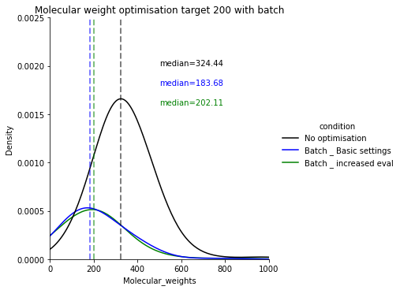

```python
sns.displot(mw200_optimisation_batch, kind='kde',x='Molecular_weights',hue='condition',bw_adjust=2, palette=['k','b','g'])
plt.axvline(x=dat_unopt_sampling.Molecular_weights.median(), linewidth=2, color='k' , linestyle='--',alpha=0.5)
plt.text(500,0.002,'median='+str("%.2f"%dat_unopt_sampling.Molecular_weights.median()))
plt.axvline(x=dat_mw200_bb.Molecular_weights.median(), linewidth=2, color='b' , linestyle='--',alpha=0.5)
plt.text(500,0.0018,'median='+str("%.2f"%dat_mw200_bb.Molecular_weights.median()),color='b')
plt.xlim(0, 1000)
plt.axvline(x=dat_mw200_ie.Molecular_weights.median(), linewidth=2, color='g' , linestyle='--',alpha=0.5)
plt.text(500,0.0016,'median='+str("%.2f"%dat_mw200_ie.Molecular_weights.median()),color='g')
plt.ylim(0, 0.0025)
plt.title('Molecular weight optimisation target 200 with batch')
plt.savefig('week2.png', bbox_inches='tight', )
```

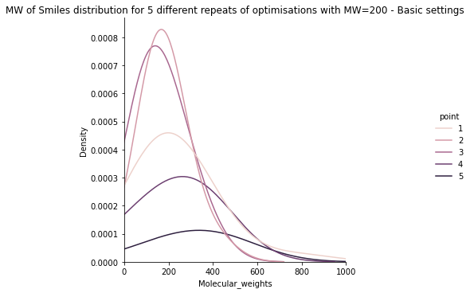

```python
sns.displot(dat_mw200_bb, kind='kde',x='Molecular_weights',hue='point',bw_adjust=2)
plt.xlim(0, 1000)
plt.title('MW of Smiles distribution for 5 different repeats of optimisations with MW=200 - Basic settings')
```

```python
Medians=[]
for i in range(1,6):
    Medians.append(dat_mw200_bb.loc[dat_mw200_bb['point'] == i].Molecular_weights.median())
print('Medians per column:', Medians)
print('Overall Median:',dat_mw200_bb.Molecular_weights.median())
```

```
Medians per column: [221.259, 169.71949999999998, 154.263, 226.255, 355.27]
Overall Median: 183.6775
```

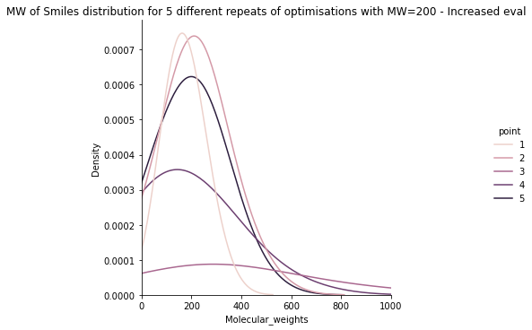

```python
sns.displot(dat_mw200_ie, kind='kde',x='Molecular_weights',hue='point',bw_adjust=2)
plt.xlim(0, 1000)
plt.title('MW of Smiles distribution for 5 different repeats of optimisations with MW=200 - Increased eval')
```

```python
Medians=[]
for i in range(1,6):
    Medians.append(dat_mw200_ie.loc[dat_mw200_ie['point'] == i].Molecular_weights.median())
print('Medians per column:', Medians)
print('Overall Median:',dat_mw200_ie.Molecular_weights.median())
```

```
Medians per column: [163.176, 209.1375, 267.72, 140.5425, 211.5025]
Overall Median: 202.111
```

**Conclusions:**

### MW target 500

```python
mw500_optimisation_batch = pd.concat([dat_unopt_sampling, dat_mw500_bb, dat_mw500_ie])
```

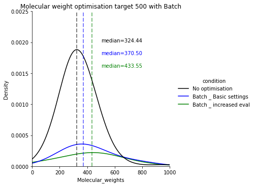

```python
sns.displot(mw500_optimisation_batch, kind='kde',x='Molecular_weights',hue='condition',bw_adjust=2, palette=['k','b','g'])
plt.axvline(x=dat_unopt_sampling.Molecular_weights.median(), linewidth=2, color='k' , linestyle='--',alpha=0.5)
plt.text(500,0.002,'median='+str("%.2f"%dat_unopt_sampling.Molecular_weights.median()))
plt.axvline(x=dat_mw500_bb.Molecular_weights.median(), linewidth=2, color='b' , linestyle='--',alpha=0.5)
plt.text(500,0.0018,'median='+str("%.2f"%dat_mw500_bb.Molecular_weights.median()),color='b')
plt.xlim(0, 1000)
plt.axvline(x=dat_mw500_ie.Molecular_weights.median(), linewidth=2, color='g' , linestyle='--',alpha=0.5)
plt.text(500,0.0016,'median='+str("%.2f"%dat_mw500_ie.Molecular_weights.median()),color='g')
plt.ylim(0, 0.0025)
plt.title('Molecular weight optimisation target 500 with Batch')
plt.savefig('week2_2.png', bbox_inches='tight', )
```

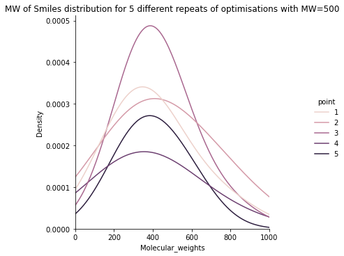

```python
sns.displot(dat_mw500_bb, kind='kde',x='Molecular_weights',hue='point',bw_adjust=2)
plt.xlim(0, 1000)
plt.title('MW of Smiles distribution for 5 different repeats of optimisations with MW=500')
```

```python
Medians=[]
for i in range(1,6):
    Medians.append(dat_mw500_bb.loc[dat_mw500_bb['point'] == i].Molecular_weights.median())
print('Medians per column:', Medians)
print('Overall Median:',dat_mw500_bb.Molecular_weights.median())
```

```
Medians per column: [342.458, 402.9435, 374.957, 351.2875, 396.544]
Overall Median: 370.497
```

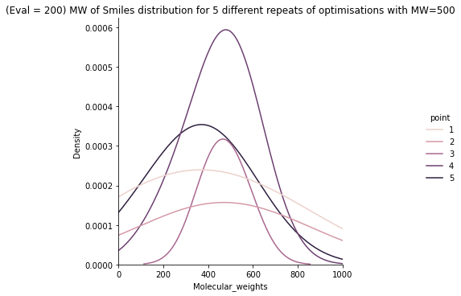

```python
sns.displot(dat_mw500_ie, kind='kde',x='Molecular_weights',hue='point',bw_adjust=2)
plt.xlim(0, 1000)
plt.title('(Eval = 200) MW of Smiles distribution for 5 different repeats of optimisations with MW=500')
```

```python
Medians=[]
for i in range(1,6):
    Medians.append(dat_mw500_ie.loc[dat_mw500_ie['point'] == i].Molecular_weights.median())
print('Medians per column:', Medians)
print('Overall Median:',dat_mw500_ie.Molecular_weights.median())
```

```
Medians per column: [365.4465, 418.50199999999995, 443.378, 475.661, 383.6365]
Overall Median: 433.552
```

### SA

```python
sa_optimisation_batch = pd.concat([dat_unopt_sampling, dat_sa, dat_sa_bb, dat_sa_ie])
```

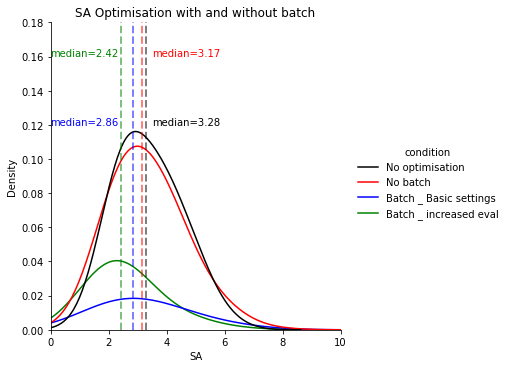

```python
sns.displot(sa_optimisation_batch, kind='kde',x='SA',hue='condition',bw_adjust=2, palette=['k','r','b','g'])
plt.axvline(x=dat_unopt_sampling.SA.median(), linewidth=2, color='k' , linestyle='--',alpha=0.5)
plt.text(3.5,0.12,'median='+str("%.2f"%dat_unopt_sampling.SA.median()))
plt.axvline(x=dat_sa.SA.median(), linewidth=2, color='r' , linestyle='--',alpha=0.5)
plt.text(3.5,0.16,'median='+str("%.2f"%dat_sa.SA.median()),color='r')
plt.axvline(x=dat_sa_bb.SA.median(), linewidth=2, color='b' , linestyle='--',alpha=0.5)
plt.text(0,0.12,'median='+str("%.2f"%dat_sa_bb.SA.median()),color='b')
plt.xlim(0, 10)
plt.axvline(x=dat_sa_ie.SA.median(), linewidth=2, color='g' , linestyle='--',alpha=0.5)
plt.text(0,0.16,'median='+str("%.2f"%dat_sa_ie.SA.median()),color='g')
plt.ylim(0, 0.18)
plt.title('SA Optimisation with and without batch')
plt.savefig('week2_3.png', bbox_inches='tight', )
```

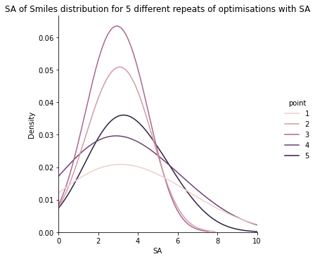

```python
sns.displot(dat_sa_bb, kind='kde',x='SA',hue='point',bw_adjust=2)
plt.xlim(0, 10)
plt.title('SA of Smiles distribution for 5 different repeats of optimisations with SA')
```

```python
Medians=[]
for i in range(1,6):
    Medians.append(dat_sa_bb.loc[dat_sa_bb['point'] == i].SA.median())
print('Medians per column:', Medians)
print('Overall Median:',dat_sa_bb.SA.median())
```

```
Medians per column: [2.767, 2.902, 2.633, 2.743, 3.121]
Overall Median: 2.856
```

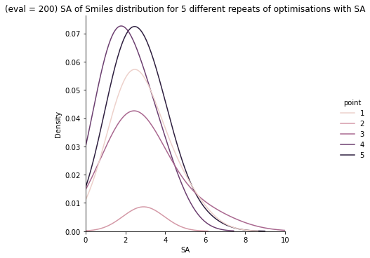

```python
sns.displot(dat_sa_ie, kind='kde',x='SA',hue='point',bw_adjust=2)
plt.xlim(0, 10)
plt.title('(eval = 200) SA of Smiles distribution for 5 different repeats of optimisations with SA')
```

```python
Medians=[]
for i in range(1,6):
    Medians.append(dat_sa_ie.loc[dat_sa_ie['point'] == i].SA.median())
print('Medians per column:', Medians)
print('Overall Median:',dat_sa_ie.SA.median())
```

```
Medians per column: [2.5620000000000003, 2.911, 2.4935, 1.841, 2.528]
Overall Median: 2.4195
```

## Appendix - Week 3

```
params=dict(dimensions=[(-5.0, 5.0)]*256,
            acq_func="EI",
            n_calls=200,
            n_initial_points=150,
            initial_point_generator='random',
            random_state=1234)
```

#### imports

```python
def file_loading_format_affinity(files):
    smiles_index=[]
    affinity=[]
    point_index=[]
    p_i=0
    for file in files:
        p_i+=1
        with open(file, 'r') as f:
            f.readline()
            for line in f:
                row = line.split()
                smiles_index.append(float(row[0]))
                affinity.append(float(row[1]))
                point_index.append(p_i)
    return point_index, smiles_index, affinity
```

```python
def file_loading_format_affinity_qed(files):
    smiles_index=[]
    affinity=[]
    qed_scores=[]
    point_index=[]
    p_i=0
    for file in files:
        p_i+=1
        with open(file, 'r') as f:
            f.readline()
            for line in f:
                row = line.split()
                smiles_index.append(float(row[0]))
                affinity.append(float(row[1]))
                qed_scores.append(float(row[2]))
                point_index.append(p_i)
    return point_index, smiles_index, affinity, qed_scores
```

```python
file_unoptimised_affinity=['Traget_unoptimised_point_'+str(i+1)+'.txt' for i in range(5)]
point_target_no, smile_target_no, affinity_target_no = file_loading_format_affinity(file_unoptimised_affinity)
dat_unopt_aff= pd.DataFrame({'Affinity': affinity_target_no, 'point':point_target_no,'condition':['Target Unoptimised']*len(point_target_no)})
```

```python
file_affinity_optimised = ['C200_Targetoptimised_point_'+str(i+1)+'.txt' for i in range(5)]
point_target, smile_target, affinity_target = file_loading_format_affinity(file_affinity_optimised)
dat_aff = pd.DataFrame({'Affinity': affinity_target, 'point': point_target,'condition':['Target Optimised']*len(point_target)})
```

```python
file_qed_affinity_optimised = ['C200_COMBOoptimised_point_'+str(i+1)+'.txt' for i in range(5)]
point_target_qed, smile_target_qed, affinity_target_qed, qed_target_qed = file_loading_format_affinity_qed(file_qed_affinity_optimised)
dat_aff_qed = pd.DataFrame({'Affinity': affinity_target_qed,'QED': qed_target_qed, 'point':point_target_qed,'condition':['Target & QED Optimised']*len(point_target_qed)})
```

```python
file_2qed_affinity_optimised = ['C200_COMBO2optimised_point_'+str(i+1)+'.txt' for i in range(5)]
point_target_qed2, smile_target_qed2, affinity_target_qed2, qed_target_qed2 = file_loading_format_affinity_qed(file_2qed_affinity_optimised)
dat_aff_qed2 = pd.DataFrame({'Affinity': affinity_target_qed2,'QED': qed_target_qed2, 'point': point_target_qed2,'condition':['Target & 2.5 QED Optimised']*len(point_target_qed2)})
```

```python
file_5qed_affinity_optimised = ['C200_COMBO5optimised_point_'+str(i+1)+'.txt' for i in range(5)]
point_target_qed5, smile_target_qed5, affinity_target_qed5, qed_target_qed5 = file_loading_format_affinity_qed(file_5qed_affinity_optimised)
dat_aff_qed5 = pd.DataFrame({'Affinity': affinity_target_qed5,'QED': qed_target_qed5, 'point': point_target_qed5,'condition':['Target & 5 QED Optimised']*len(point_target_qed5)})
```

```python
file_05qed_affinity_optimised = ['C200_COMBO05optimised_point_'+str(i+1)+'.txt' for i in range(5)]
point_target_qed05, smile_target_qed05, affinity_target_qed05, qed_target_qed05 = file_loading_format_affinity_qed(file_05qed_affinity_optimised)
dat_aff_qed05 = pd.DataFrame({'Affinity': affinity_target_qed05,'QED': qed_target_qed05, 'point': point_target_qed05,'condition':['Target & 0.5 QED Optimised']*len(point_target_qed05)})
```

```python
file_qed_05affinity_optimised = ['C200_COMBO051optimised_point_'+str(i+1)+'.txt' for i in range(5)]
point_target05_qed, smile_target05_qed, affinity_target05_qed, qed_target05_qed = file_loading_format_affinity_qed(file_qed_05affinity_optimised)
dat_aff05_qed = pd.DataFrame({'Affinity': affinity_target05_qed,'QED': qed_target05_qed, 'point': point_target05_qed,'condition':['0.5 Target & QED Optimised']*len(point_target05_qed)})
```

### Target optimisation

```python
target_optimisation = pd.concat([dat_unopt_aff, dat_aff])
```

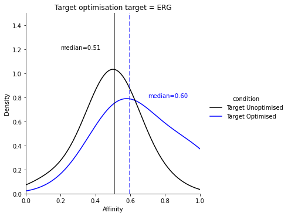

```python
sns.displot(target_optimisation, kind='kde',x='Affinity',hue='condition',bw_adjust=2, palette=['k','b'])
plt.axvline(x=dat_unopt_aff.Affinity.median(), linewidth=2, color='k' ,alpha=0.5)
plt.text(0.2,1.2,'median='+str("%.2f"%dat_unopt_aff.Affinity.median()))
plt.axvline(x=dat_aff.Affinity.median(), linewidth=2, color='b' , linestyle='--',alpha=0.5)
plt.text(0.7,0.8,'median='+str("%.2f"%dat_aff.Affinity.median()),color='b')
plt.xlim(0, 1)
plt.ylim(0, 1.5)
plt.title('Target optimisation target = ERG')
plt.savefig('week3.png', bbox_inches='tight')
```

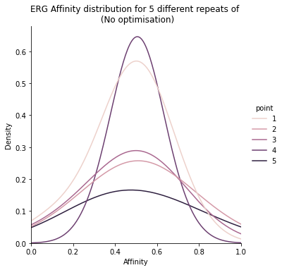

```python
sns.displot(dat_unopt_aff, kind='kde',x='Affinity',hue='point',bw_adjust=2)
plt.xlim(0, 1)
plt.title('ERG Affinity distribution for 5 different repeats of \n (No optimisation)')
```

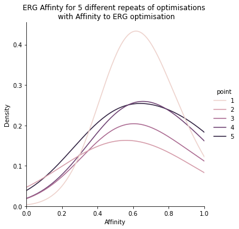

```python
sns.displot(dat_aff, kind='kde',x='Affinity',hue='point',bw_adjust=2)
plt.xlim(0, 1)
plt.title('ERG Affinty for 5 different repeats of optimisations \n with Affinity to ERG optimisation')
```

### Combined Target+QED

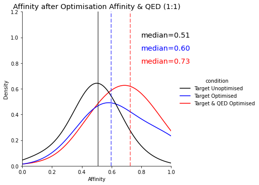

```python
target_qed_optimisation=pd.concat([dat_unopt_aff,dat_aff,dat_aff_qed])
sns.displot(target_qed_optimisation, kind='kde',x='Affinity',hue='condition',bw_adjust=2, palette=['k','b','r'],height=5)
plt.axvline(x=dat_unopt_aff.Affinity.median(), linewidth=2, color='k' ,alpha=0.5)
plt.text(0.8,1,'median='+str("%.2f"%dat_unopt_aff.Affinity.median()),fontsize='x-large')
plt.axvline(x=dat_aff.Affinity.median(), linewidth=2, color='b' , linestyle='--',alpha=0.5)
plt.text(0.8,0.9,'median='+str("%.2f"%dat_aff.Affinity.median()),color='b',fontsize='x-large')
plt.axvline(x=dat_aff_qed.Affinity.median(), linewidth=2, color='r' , linestyle='--',alpha=0.5)
plt.text(0.8,0.8,'median='+str("%.2f"%dat_aff_qed.Affinity.median()),color='r',fontsize='x-large')
plt.xlim(0, 1)
plt.ylim(0, 1.2)
plt.title('Affinity after Optimisation Affinity & QED (1:1)',fontsize='x-large')
plt.savefig('week3_2.png', bbox_inches='tight' )
```

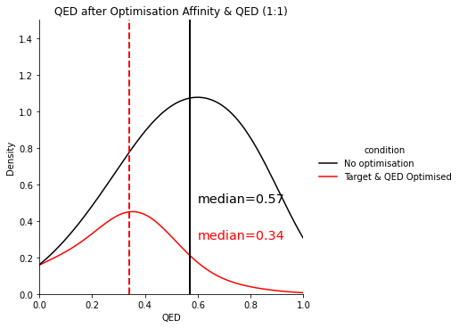

```python
target_qed_optimisation_qed=pd.concat([dat_unopt_sampling,dat_aff_qed])
sns.displot(target_qed_optimisation_qed, kind='kde',x='QED',hue='condition',bw_adjust=2,palette=['k','r'],height=5)
plt.axvline(x=dat_unopt_sampling.QED.median(), linewidth=2, color='k' )
plt.text(0.6,0.5,'median='+str("%.02f"%dat_unopt_sampling.QED.median()),fontsize='x-large')
plt.axvline(x=dat_aff_qed.QED.median(), linewidth=2, color='r' , linestyle = '--')
plt.text(0.6,0.3,'median='+str("%.02f"%dat_aff_qed.QED.median()),color='r',fontsize='x-large')
plt.xlim(0, 1)
plt.ylim(0, 1.5)
plt.title('QED after Optimisation Affinity & QED (1:1)')
plt.savefig('week3_3.png', bbox_inches='tight' )
```

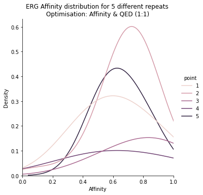

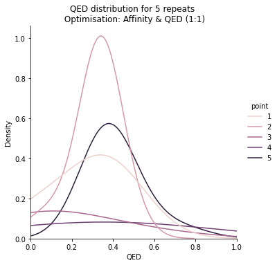

```python
sns.displot(dat_aff_qed, kind='kde',x='Affinity',hue='point',bw_adjust=2)
plt.xlim(0, 1)
plt.title('ERG Affinity distribution for 5 different repeats \n Optimisation: Affinity & QED (1:1) ')
sns.displot(dat_aff_qed, kind='kde',x='QED',hue='point',bw_adjust=2)
plt.xlim(0, 1)
plt.title('QED distribution for 5 repeats \n Optimisation: Affinity & QED (1:1)')
```

### Other optimisation ratios

```python
target_qed_ratio_optimisation = pd.concat([dat_unopt_aff,dat_aff,dat_aff_qed, dat_aff_qed2,dat_aff_qed5,dat_aff_qed05,dat_aff05_qed])
```

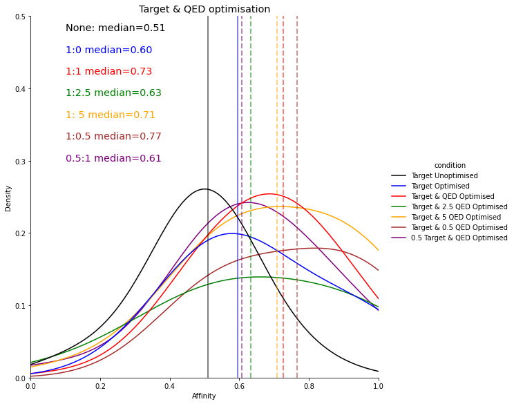

```python
sns.displot(target_qed_ratio_optimisation, height=8,kind='kde',x='Affinity',hue='condition',bw_adjust=2, palette=['k','b','r','g','orange','brown','purple'])
plt.axvline(x=dat_unopt_aff.Affinity.median(), linewidth=2, color='k' ,alpha=0.5)
plt.text(0.1,0.48,'None: median='+str("%.2f"%dat_unopt_aff.Affinity.median()),fontsize='x-large')
plt.axvline(x=dat_aff.Affinity.median(), linewidth=2, color='b' ,alpha=0.5)
plt.text(0.1,0.45,'1:0 median='+str("%.2f"%dat_aff.Affinity.median()),color='b',fontsize='x-large')
plt.axvline(x=dat_aff_qed.Affinity.median(), linewidth=2, color='r' , linestyle='--',alpha=0.5)
plt.text(0.1,0.42,'1:1 median='+str("%.2f"%dat_aff_qed.Affinity.median()),color='r',fontsize='x-large')
plt.axvline(x=dat_aff_qed2.Affinity.median(), linewidth=2, color='g' , linestyle='--',alpha=0.5)
plt.text(0.1,0.39,'1:2.5 median='+str("%.2f"%dat_aff_qed2.Affinity.median()),color='g',fontsize='x-large')
plt.axvline(x=dat_aff_qed5.Affinity.median(), linewidth=2, color='orange' , linestyle='--',alpha=0.5)
plt.text(0.1,0.36,'1: 5 median='+str("%.2f"%dat_aff_qed5.Affinity.median()),color='orange',fontsize='x-large')
plt.axvline(x=dat_aff_qed05.Affinity.median(), linewidth=2, color='brown' , linestyle='--',alpha=0.5)
plt.text(0.1,0.33,'1:0.5 median='+str("%.2f"%dat_aff_qed05.Affinity.median()),color='brown',fontsize='x-large')
plt.axvline(x=dat_aff05_qed.Affinity.median(), linewidth=2, color='purple' , linestyle='--',alpha=0.5)
plt.text(0.1,0.30,'0.5:1 median='+str("%.2f"%dat_aff05_qed.Affinity.median()),color='purple',fontsize='x-large')
plt.xlim(0, 1)
plt.ylim(0, 0.5)
plt.title('Target & QED optimisation',fontsize='x-large')
plt.savefig('week3-4.png', bbox_inches='tight')
```

```python
target_qed_ratio_optimisation_qed = pd.concat([dat_unopt_sampling,dat_aff_qed, dat_aff_qed2,dat_aff_qed5,dat_aff_qed05,dat_aff05_qed])
```

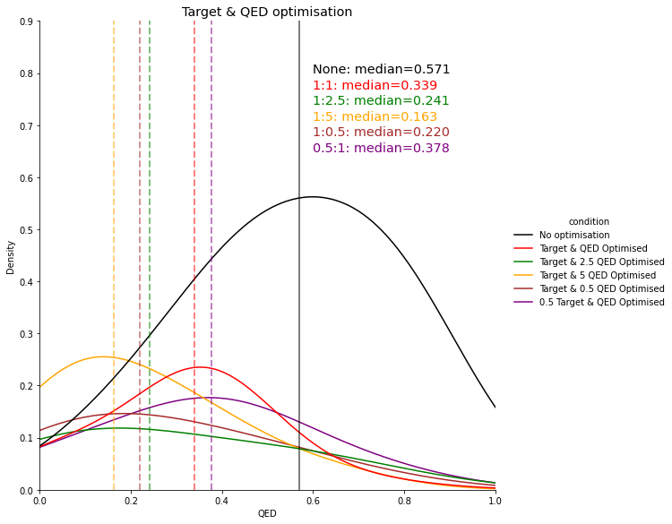

```python
sns.displot(target_qed_ratio_optimisation_qed, kind='kde',x='QED',hue='condition',bw_adjust=2,height=8,palette=['k','r','g','orange','brown','purple'])
plt.axvline(x=dat_unopt_sampling.QED.median(), linewidth=2, color='k' ,alpha=0.5)
plt.text(0.6,0.8,'None: median='+str("%.03f"%dat_unopt_sampling.QED.median()),fontsize='x-large')
plt.axvline(x=dat_aff_qed.QED.median(), linewidth=2, color='r' ,linestyle='--',alpha=0.5)
plt.text(0.6,0.77,'1:1: median='+str("%.03f"%dat_aff_qed.QED.median()),color='r',fontsize='x-large')
plt.axvline(x=dat_aff_qed2.QED.median(), linewidth=2, color='g' ,linestyle='--',alpha=0.5)
plt.text(0.6,0.74,'1:2.5: median='+str("%.03f"%dat_aff_qed2.QED.median()),color='g',fontsize='x-large')
plt.axvline(x=dat_aff_qed5.QED.median(), linewidth=2, color='orange' ,linestyle='--',alpha=0.5)
plt.text(0.6,0.71,'1:5: median='+str("%.03f"%dat_aff_qed5.QED.median()),color='orange',fontsize='x-large')
plt.axvline(x=dat_aff_qed05.QED.median(), linewidth=2, color='brown' ,linestyle='--',alpha=0.5)
plt.text(0.6,0.68,'1:0.5: median='+str("%.03f"%dat_aff_qed05.QED.median()),color='brown',fontsize='x-large')
plt.axvline(x=dat_aff05_qed.QED.median(), linewidth=2, color='purple' , linestyle='--',alpha=0.5)
plt.text(0.6,0.65,'0.5:1: median='+str("%.03f"%dat_aff05_qed.QED.median()),color='purple',fontsize='x-large')
plt.xlim(0, 1)
plt.ylim(0, 0.9)
plt.title('Target & QED optimisation',fontsize='x-large')
plt.savefig('week3-5.png', bbox_inches='tight')
```

## Appendix - Week 4 onwards

#### imports

```python
file_1qed_05affinity_optimised = ['C200_COMBO051BIoptimised_point_'+str(i+1)+'.txt' for i in range(5)]
point_05target_1qed, smile_05target_1qed, affinity_05target_1qed, qed_05target_1qed = file_loading_format_affinity_qed(file_1qed_05affinity_optimised)
dat_05target_1qed = pd.DataFrame({'Affinity': affinity_05target_1qed,'QED': qed_05target_1qed, 'point': point_05target_1qed,'condition':['0.5 Target & 1 QED Optimised']*len(point_05target_1qed)})
```

```python
file_1qed_1affinity_optimised = ['C200_COMBO11BIoptimised_point_'+str(i+1)+'.txt' for i in range(5)]
point_1target_1qed, smile_1target_1qed, affinity_1target_1qed, qed_1target_1qed = file_loading_format_affinity_qed(file_1qed_1affinity_optimised)
dat_1target_1qed = pd.DataFrame({'Affinity': affinity_1target_1qed,'QED': qed_1target_1qed, 'point': point_1target_1qed,'condition':['1 Target & 1 QED Optimised']*len(point_1target_1qed)})
```

```python
file_2qed_1affinity_optimised = ['C200_COMBO12BIoptimised_point_'+str(i+1)+'.txt' for i in range(5)]
point_1target_2qed, smile_1target_2qed, affinity_1target_2qed, qed_1target_2qed = file_loading_format_affinity_qed(file_2qed_1affinity_optimised)
dat_1target_2qed = pd.DataFrame({'Affinity': affinity_1target_2qed,'QED': qed_1target_2qed, 'point': point_1target_2qed,'condition':['1 Target & 2 QED Optimised']*len(point_1target_2qed)})
```

```python
file_1qed_05affinity_optimised_inc = ['C200_COMBO051BI300optimised_point_'+str(i+1)+'.txt' for i in range(5)]
point_05target_1qed_inc, smile_05target_1qed_inc, affinity_05target_1qed_inc, qed_05target_1qed_inc = file_loading_format_affinity_qed(file_1qed_05affinity_optimised_inc)
dat_05target_1qed_inc = pd.DataFrame({'Affinity': affinity_05target_1qed_inc,'QED': qed_05target_1qed_inc, 'point': point_05target_1qed_inc,'condition':['0.5 Target & 1 QED Optimised - increased eval 300']*len(point_05target_1qed_inc)})
```

```python
def file_loading_format_affinity_qed_sa(files):
    smiles_index=[]
    affinity=[]
    qed_scores=[]
    sa_scores=[]
    point_index=[]
    p_i=0
    for file in files:
        p_i+=1
        with open(file, 'r') as f:
            f.readline()
            for line in f:
                row = line.split()
                smiles_index.append(float(row[0]))
                affinity.append(float(row[1]))
                qed_scores.append(float(row[2]))
                sa_scores.append(float(row[3]))
                point_index.append(p_i)
    return point_index, smiles_index, affinity, qed_scores, sa_scores
```

```python
file_1qed_05affinity_1sa_optimised = ['SA_Target_QED_optimised_point_'+str(i+1)+'.txt' for i in range(5)]
point_05target_1qed_1sa, smile_05target_1qed_1sa, affinity_05target_1qed_1sa, qed_05target_1qed_1sa, sa_05target_1qed_1sa = file_loading_format_affinity_qed_sa(file_1qed_05affinity_1sa_optimised)
dat_05target_1qed_1sa = pd.DataFrame({'Affinity': affinity_05target_1qed_1sa,'QED': qed_05target_1qed_1sa,'SA':sa_05target_1qed_1sa, 'point':point_05target_1qed_1sa,'condition':['0.5 Target & 1 QED & 1 SA Optimised']*len(point_05target_1qed_1sa)})
```

```python
file_1qed_05affinity_1sa_optimised_inc = ['SA_Target_QED_Poptimised_point_'+str(i+1)+'.txt' for i in range(5)]
point_05target_1qed_1sa_inc, smile_05target_1qed_1sa_inc, affinity_05target_1qed_1sa_inc, qed_05target_1qed_1sa_inc, sa_05target_1qed_1sa_inc = file_loading_format_affinity_qed_sa(file_1qed_05affinity_1sa_optimised_inc)
dat_05target_1qed_1sa_inc = pd.DataFrame({'Affinity': affinity_05target_1qed_1sa_inc,'QED': qed_05target_1qed_1sa_inc,'SA':sa_05target_1qed_1sa_inc, 'point': point_05target_1qed_1sa_inc,'condition':['0.5 Target & 1 QED & 1 SA Optimised - Increased eval']*len(point_05target_1qed_1sa_inc)})
```

```python
target_qed_sa_optimisation=pd.concat([dat_unopt_aff, dat_aff, dat_1target_1qed, dat_1target_2qed, dat_05target_1qed, dat_05target_1qed_inc, dat_05target_1qed_1sa, dat_05target_1qed_1sa_inc])
```

```python
target_qed_sa_optimisation_qed=pd.concat([dat_unopt_sampling, dat_1target_1qed, dat_1target_2qed, dat_05target_1qed, dat_05target_1qed_inc, dat_05target_1qed_1sa, dat_05target_1qed_1sa_inc])
```

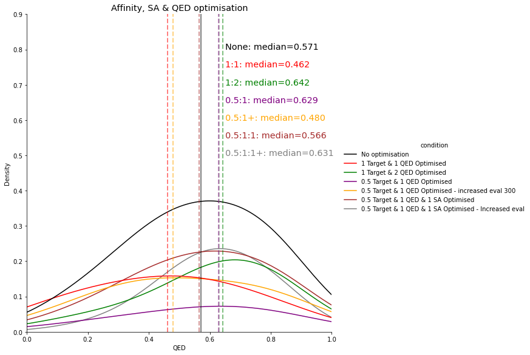

```python
sns.displot(target_qed_sa_optimisation_qed, kind='kde',x='QED',hue='condition',bw_adjust=2,height=8,palette=['k','r','g','purple','orange','brown','grey'])
plt.axvline(x=dat_unopt_sampling.QED.median(), linewidth=2, color='k' ,linestyle='-',alpha=0.5)
plt.text(0.65,0.8,'None: median='+str("%.03f"%dat_unopt_sampling.QED.median()),fontsize='x-large')
plt.axvline(x=dat_1target_1qed.QED.median(), linewidth=2, color='r' ,linestyle='--',alpha=0.5)
plt.text(0.65,0.75,'1:1: median='+str("%.03f"%dat_1target_1qed.QED.median()),color='r',fontsize='x-large')
plt.axvline(x=dat_1target_2qed.QED.median(), linewidth=2, color='g' ,linestyle='--',alpha=0.5)
plt.text(0.65,0.7,'1:2: median='+str("%.03f"%dat_1target_2qed.QED.median()),color='g',fontsize='x-large')
plt.text(0.65,0.65,'0.5:1: median='+str("%.03f"%dat_05target_1qed.QED.median()),color='purple',fontsize='x-large')
plt.axvline(x=dat_05target_1qed.QED.median(), linewidth=2, color='purple' ,linestyle='--',alpha=0.5)
plt.text(0.65,0.6,'0.5:1+: median='+str("%.03f"%dat_05target_1qed_inc.QED.median()),color='orange',fontsize='x-large')
plt.axvline(x=dat_05target_1qed_inc.QED.median(), linewidth=2, color='orange' ,linestyle='--',alpha=0.5)
plt.text(0.65,0.55,'0.5:1:1: median='+str("%.03f"%dat_05target_1qed_1sa.QED.median()),color='brown',fontsize='x-large')
plt.axvline(x=dat_05target_1qed_1sa.QED.median(), linewidth=2, color='brown' ,linestyle='--',alpha=0.5)
plt.text(0.65,0.5,'0.5:1:1+: median='+str("%.03f"%dat_05target_1qed_1sa_inc.QED.median()),color='grey',fontsize='x-large')
plt.axvline(x=dat_05target_1qed_1sa_inc.QED.median(), linewidth=2, color='grey' ,linestyle='--',alpha=0.5)
plt.xlim(0, 1)
plt.ylim(0, 0.9)
plt.title('Affinity, SA & QED optimisation',fontsize='x-large')
plt.savefig('week4.png', bbox_inches='tight' )
```

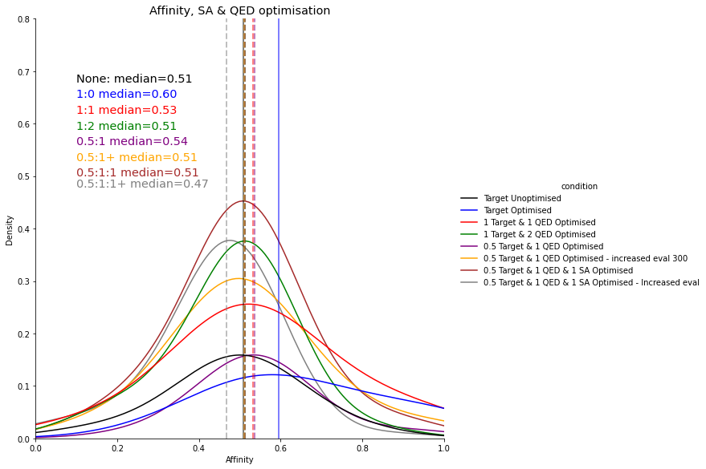

```python
sns.displot(target_qed_sa_optimisation, height=8,kind='kde',x='Affinity',hue='condition',bw_adjust=2, palette=['k','b','r','g','purple','orange','brown','grey'])
plt.axvline(x=dat_unopt_aff.Affinity.median(), linewidth=2, color='k' ,alpha=0.5)
plt.text(0.1,0.68,'None: median='+str("%.2f"%dat_unopt_aff.Affinity.median()),fontsize='x-large')
plt.axvline(x=dat_aff.Affinity.median(), linewidth=2, color='b' ,alpha=0.5)
plt.text(0.1,0.65,'1:0 median='+str("%.2f"%dat_aff.Affinity.median()),color='b',fontsize='x-large')
plt.axvline(x=dat_1target_1qed.Affinity.median(), linewidth=2, color='r' , linestyle='--',alpha=0.5)
plt.text(0.1,0.62,'1:1 median='+str("%.2f"%dat_1target_1qed.Affinity.median()),color='r',fontsize='x-large')
plt.axvline(x=dat_1target_2qed.Affinity.median(), linewidth=2, color='g' , linestyle='--',alpha=0.5)
plt.text(0.1,0.59,'1:2 median='+str("%.2f"%dat_1target_2qed.Affinity.median()),color='g',fontsize='x-large')
plt.axvline(x=dat_05target_1qed.Affinity.median(), linewidth=2, color='purple' , linestyle='--',alpha=0.5)
plt.text(0.1,0.56,'0.5:1 median='+str("%.2f"%dat_05target_1qed.Affinity.median()),color='purple',fontsize='x-large')
plt.axvline(x=dat_05target_1qed_inc.Affinity.median(), linewidth=2, color='orange' , linestyle='--',alpha=0.5)
plt.text(0.1,0.53,'0.5:1+ median='+str("%.2f"%dat_05target_1qed_inc.Affinity.median()),color='orange',fontsize='x-large')
plt.axvline(x=dat_05target_1qed_1sa.Affinity.median(), linewidth=2, color='brown' , linestyle='--',alpha=0.5)
plt.text(0.1,0.5,'0.5:1:1 median='+str("%.2f"%dat_05target_1qed_1sa.Affinity.median()),color='brown',fontsize='x-large')
plt.axvline(x=dat_05target_1qed_1sa_inc.Affinity.median(), linewidth=2, color='grey' , linestyle='--',alpha=0.5)
plt.text(0.1,0.48,'0.5:1:1+ median='+str("%.2f"%dat_05target_1qed_1sa_inc.Affinity.median()),color='grey',fontsize='x-large')
plt.xlim(0, 1)
plt.ylim(0, 0.8)
plt.title('Affinity, SA & QED optimisation',fontsize='x-large')
plt.savefig('week4_2.png', bbox_inches='tight' )
```

```python
SA_optimisation=pd.concat([dat_unopt_sampling, dat_sa, dat_sa_bb, dat_sa_ie, dat_05target_1qed_1sa, dat_05target_1qed_1sa_inc])
```

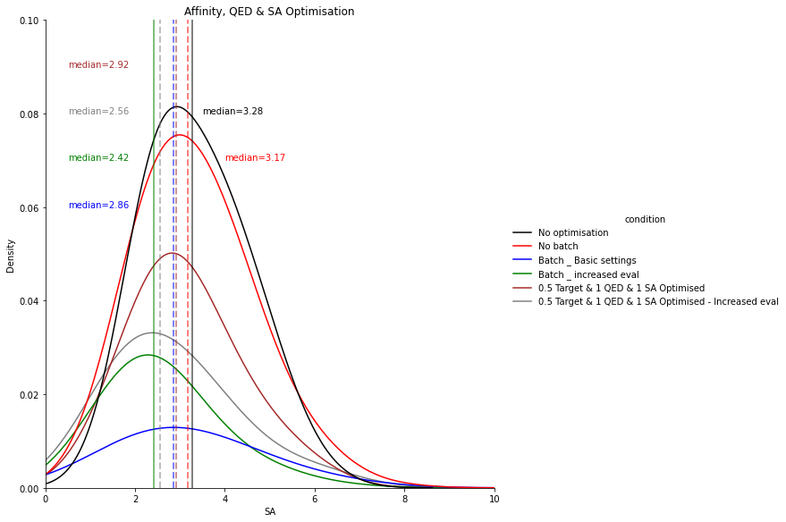

```python
sns.displot(SA_optimisation, kind='kde',height=8, x='SA',hue='condition',bw_adjust=2, palette=['k','r','b','g','brown','grey'])
plt.axvline(x=dat_unopt_sampling.SA.median(), linewidth=2, color='k' , linestyle='-',alpha=0.5)
plt.text(3.5,0.08,'median='+str("%.2f"%dat_unopt_sampling.SA.median()))
plt.axvline(x=dat_sa.SA.median(), linewidth=2, color='r' , linestyle='--',alpha=0.5)
plt.text(4,0.07,'median='+str("%.2f"%dat_sa.SA.median()),color='r')
plt.axvline(x=dat_sa_bb.SA.median(), linewidth=2, color='b' , linestyle='--',alpha=0.5)
plt.text(0.5,0.06,'median='+str("%.2f"%dat_sa_bb.SA.median()),color='b')
plt.xlim(0, 10)
plt.axvline(x=dat_sa_ie.SA.median(), linewidth=2, color='g' , linestyle='-',alpha=0.5)
plt.text(0.5,0.07,'median='+str("%.2f"%dat_sa_ie.SA.median()),color='g')
plt.axvline(x=dat_05target_1qed_1sa.SA.median(), linewidth=2, color='brown' , linestyle='--',alpha=0.5)
plt.text(0.5,0.09,'median='+str("%.2f"%dat_05target_1qed_1sa.SA.median()),color='brown')
plt.axvline(x=dat_05target_1qed_1sa_inc.SA.median(), linewidth=2, color='grey' , linestyle='--',alpha=0.5)
plt.text(0.5,0.08,'median='+str("%.2f"%dat_05target_1qed_1sa_inc.SA.median()),color='grey')

plt.ylim(0, 0.1)
plt.title('Affinity, QED & SA Optimisation')
plt.savefig('week4_3.png', bbox_inches='tight' )
```